# Demo of RregressPkg::plot_replace_missing()

```r
library(knitr)
library(kableExtra)
library(data.table)
library(ggplot2)
library(mlbench)
library(dplyr)
library(RregressPkg)
library(RplotterPkg)
```

## Simple example

1. Create the data.frame with NA’s and NaN’s and other values considered missing:

```r
set.seed(5648)
df <- data.frame(
  x = 1:20,
  y = LETTERS[1:20],
  z = rnorm(20, mean = 10, sd = 2.1)
)
df$x[1:2] <- NA
df$x[[5]] <- 9999
df$x[[8]] <- 1111
df$x[12:15] <- NaN
df$z[8:9] <- NaN
df$z[18:19] <- NA
```

2. Show the counts of missing values:

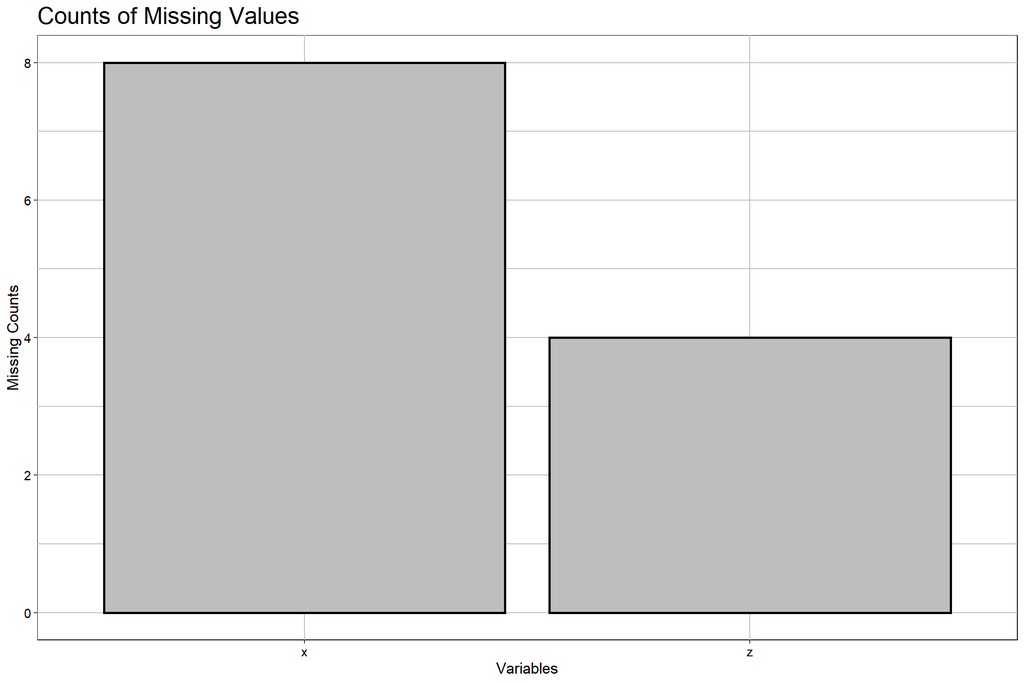

```r
missing_lst <- RregressPkg::plot_replace_missing(
  df = df,
  variables = c("x", "z"),
  miss_values = c(1111, 9999),
  title = "Counts of Missing Values"
)
missing_lst$missing_plot
```

```r
missing_lst <- RregressPkg::plot_replace_missing(
  df = df,
  variables = c("x", "z"),
  miss_values = c(1111, 9999),
  replace_fun = "median"
)
colnames(missing_lst$replacement_df) <- c("new_x", "new_y", "new_z")
df_all <- cbind(df, missing_lst$replacement_df)

RplotterPkg::create_table(
  x = df_all,
  caption = "Missing Replaced With Median Values",
  scroll_height = "250px",
  fixed_thead = T)
```

Missing Replaced With Median Values

| x | y | z | new_x | new_y | new_z |
| --- | --- | --- | --- | --- | --- |
| NA | A | 8.482503 | 10.5 | A | 8.482503 |
| NA | B | 9.229829 | 10.5 | B | 9.229829 |
| 3 | C | 4.787938 | 3.0 | C | 4.787938 |
| 4 | D | 9.179752 | 4.0 | D | 9.179752 |
| 9999 | E | 11.779020 | 10.5 | E | 11.779020 |
| 6 | F | 10.081797 | 6.0 | F | 10.081797 |
| 7 | G | 6.862204 | 7.0 | G | 6.862204 |
| 1111 | H | NA | 10.5 | H | 9.260329 |
| 9 | I | NA | 9.0 | I | 9.260329 |
| 10 | J | 9.761310 | 10.0 | J | 9.761310 |
| 11 | K | 12.297257 | 11.0 | K | 12.297257 |
| NA | L | 11.396166 | 10.5 | L | 11.396166 |
| NA | M | 8.838840 | 10.5 | M | 8.838840 |
| NA | N | 8.304888 | 10.5 | N | 8.304888 |
| NA | O | 11.882333 | 10.5 | O | 11.882333 |
| 16 | P | 6.396837 | 16.0 | P | 6.396837 |
| 17 | Q | 9.290829 | 17.0 | Q | 9.290829 |
| 18 | R | NA | 18.0 | R | 9.260329 |
| 19 | S | NA | 19.0 | S | 9.260329 |
| 20 | T | 9.915196 | 20.0 | T | 9.915196 |

4. Replace missing values using “next observation carried backward”:

```r
missing_lst <- RregressPkg::plot_replace_missing(
  df = df,
  variables = c("x", "z"),
  miss_values = c(1111, 9999),
  replace_fun = "nocb"
)

colnames(missing_lst$replacement_df) <- c("new_x", "new_y", "new_z")
df_all <- cbind(df, missing_lst$replacement_df)

RplotterPkg::create_table(
  x = df_all,
  caption = "Missing Replaced With 'nocb' Values",
  scroll_height = "250px",
  fixed_thead = T)
```

Missing Replaced With ‘nocb’ Values

| x | y | z | new_x | new_y | new_z |
| --- | --- | --- | --- | --- | --- |
| NA | A | 8.482503 | 3 | A | 8.482503 |
| NA | B | 9.229829 | 3 | B | 9.229829 |
| 3 | C | 4.787938 | 3 | C | 4.787938 |
| 4 | D | 9.179752 | 4 | D | 9.179752 |
| 9999 | E | 11.779020 | 6 | E | 11.779020 |
| 6 | F | 10.081797 | 6 | F | 10.081797 |
| 7 | G | 6.862204 | 7 | G | 6.862204 |
| 1111 | H | NA | 9 | H | 9.761310 |
| 9 | I | NA | 9 | I | 9.761310 |
| 10 | J | 9.761310 | 10 | J | 9.761310 |
| 11 | K | 12.297257 | 11 | K | 12.297257 |
| NA | L | 11.396166 | 16 | L | 11.396166 |
| NA | M | 8.838840 | 16 | M | 8.838840 |
| NA | N | 8.304888 | 16 | N | 8.304888 |
| NA | O | 11.882333 | 16 | O | 11.882333 |
| 16 | P | 6.396837 | 16 | P | 6.396837 |
| 17 | Q | 9.290829 | 17 | Q | 9.290829 |
| 18 | R | NA | 18 | R | 9.915196 |
| 19 | S | NA | 19 | S | 9.915196 |
| 20 | T | 9.915196 | 20 | T | 9.915196 |

## Soybean example

1. Set up the data:

There are 683 observations and 36 variables. The class of the measurement variables in Soybean is either “factor” or “ordered”. We will ignore the first variable *Class* since it is character type and convert all others to numeric.

```r
data("Soybean", package = "mlbench")
for(i in 2:ncol(Soybean)){
  Soybean[,i] <- as.numeric(Soybean[,i])
}
```

2. Set the columns of interest and insert some missing values. *date* variable has one missing value. For testing assign 2 missing values to *date* variable for a total of 3. *leaves* variable has no missing values. For testing assign 5 missing values to the *leaves* variable for a total of 5.

```r
columns_of_interest <- colnames(Soybean)[2:ncol(Soybean)]

Soybean$date[[3]] <- NA
Soybean$date[[4]] <- 99
Soybean$leaves[[4]] <-  NA
Soybean$leaves[[5]] <-  "N/A"
Soybean$leaves[[6]] <-  "na"
Soybean$leaves[[7]] <- NA
Soybean$leaves[[8]] <- NaN
```

3. Get a count of the missing values:

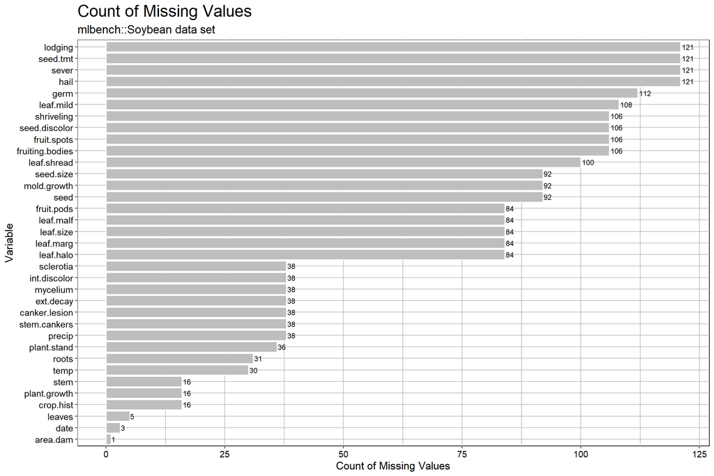

```r
soybean_missing_lst <- RregressPkg::plot_replace_missing(
  df = Soybean,
  variables = columns_of_interest,
  miss_values = c("N/A", "na", 99),
  title = "Count of Missing Values",
  subtitle = "mlbench::Soybean data set",
  x_title = "Variable",
  y_title = "Count of Missing Values",
  bar_size = 0.6,
  bar_color = "white",
  bar_labels = TRUE,
  bar_label_size = 3,
  do_coord_flip = TRUE,
  order_bars = "asc"
)
soybean_missing_lst$missing_plot
```

4. Apply a user defined function for replacing missing values:

```r
missing_val_fun <- function(x){
  xx <- as.numeric(x)
  return((max(xx) - min(xx))/2)
}
soybean_missing_lst <- RregressPkg::plot_replace_missing(
  df = Soybean,
  variables = columns_of_interest,
  replace_fun = missing_val_fun,
  miss_values = c("N/A", "na", 99),
  title = "Count of Missing Values",
  subtitle = "mlbench::Soybean data set",
  x_title = "Variable",
  y_title = "Count of Missing Values",
  bar_size = 0.6,
  bar_color = "white",
  bar_labels = TRUE,
  bar_label_size = 3,
  do_coord_flip = TRUE,
  order_bars = "asc"
)
soybean_missing_lst$replacement_df %>%
  select(date, leaves) %>%
  head(n = 10)
```

```
##     date leaves
##  1:    7    2.0
##  2:    5    2.0
##  3:    3    2.0
##  4:    3    0.5
##  5:    7    0.5
##  6:    6    0.5
##  7:    6    0.5
##  8:    5    0.5
##  9:    7    2.0
## 10:    5    2.0
```

Note that *date* variable now has a value 3 and *leaves* variable now has a value of 0.5 for their missing values.

5. Run `RregressPkg::plot_replace_missing()` on the replacement data.frame to check on missing values:

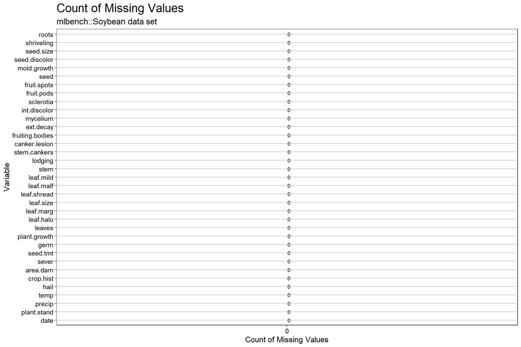

```r
soybean_missing_lst <- RregressPkg::plot_replace_missing(
  df = soybean_missing_lst$replacement_df,
  variables = columns_of_interest,
  miss_values = c("N/A", "na", 99),
  title = "Count of Missing Values",
  subtitle = "mlbench::Soybean data set",
  x_title = "Variable",
  y_title = "Count of Missing Values",
  bar_size = 0.6,
  bar_color = "white",
  bar_labels = TRUE,
  bar_label_size = 3,
  do_coord_flip = TRUE,
  order_bars = "asc",
  y_major_breaks = c(0,1,2)
)
soybean_missing_lst$missing_plot
```